# Taller 1 - Análisis Exploratorio de Datos, Universidad ICESI

María Paula Fernández, Cristian Palechor, Jorge Antonio Morales

18/2/2022

# Contexto

El examen prueba saber TyT, es un examen que deben presentar todos los estudiantes proximos a graduarse de sus estudios tecnicos profesionales y tecnológicos. Se evalua en cinco modulos:

- Lectura Crítica
- Razonamiento cuantitativo
- Competencias ciudadanas
- Comunicación escrita
- Inglés

## Cargue de datos y procedimientos iniciales

El objetivo de documento, es analizar la base de datos de los resultados de los estudiantes a nivel nacional que realizaron las pruebas en el año 2016. La base entregada para el estudio contiene 53040 observaciones y 104 columnas, a lo largo del desarrollo se irá depurando algunas variables de interés.

Inicialmente, se carga la base para el análisis, y eliminamos columnas hasta obtener 35 columnas que van a ser utilizadas en el ejercicio, posterior se filtra la información por estudiantes que tienen sus resultados para Publicar y sean de nacionalidad colombianos.

Por otro lado, se agregan dos columnas adicionales:

- ESTU_EDAD: teniendo en cuenta la fecha de nacimiento y la fecha de presentación del examen.
- ESTU_INGLES_SUPERIOR: Sí si el estudiante está en el nivel de inglés B1 o B2, No si no lo está.

Posteriormente, se revisa de que no hayan datos duplicados.

## Verificación y limpieza de anomalías

### Variable “ESTU_EDAD”

La variable es de tipo numérico y se observa que existe un campo vacío, existen datos inválidos y datos atípicos.

```
##                MEDIDA          VALOR
## 1       Observaciones 52664.00000000
## 2              Mínimo    -8.00000000
## 3               1er Q    20.00000000
## 4               Media    24.95873842
## 5             Mediana    23.00000000
## 6            Desv Est     6.96524086
## 7               3er Q    28.00000000
## 8              Máximo    71.00000000
## 9           Asimetría     1.50850201
## 10           Curtosis     2.95731784
## 11      atípico leve<     8.00000000
## 12      atípico leve>    40.00000000
## 13   atípico extremo<    -4.00000000
## 14   atípico extremo>    52.00000000
## 15      Err Est Media     0.03035143
## 16   IC(95%) Media Up    25.01822723
## 17 IC(95%) Media Down    24.89924961
```

Teniendo en cuenta la gráfica de caja de bigotes, se logran observar bastantes valores atípicos. Sin embargo, no se tomarán como atípicos los que se encuentran en el nivel superior debido a que los adultos mayores pueden realizar las pruebas.

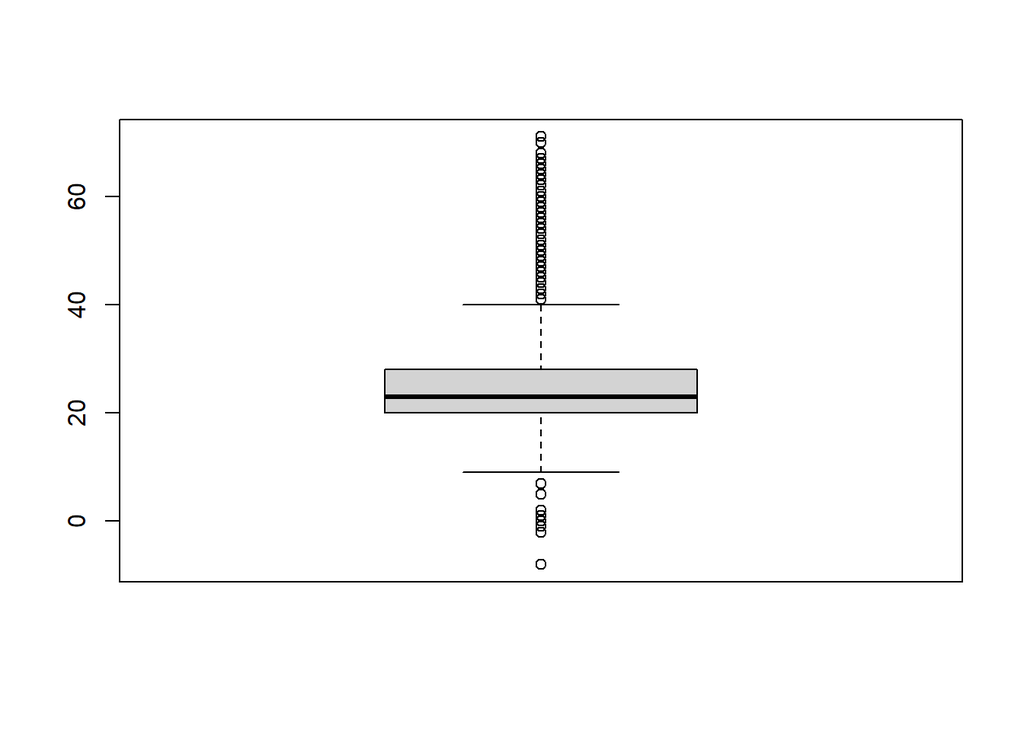

Diagrama de bigotes de las edades

#### **Datos atípicos:**

```
## # A tibble: 3 x 2
##   `base$ESTU_EDAD > 0 & base$ESTU_EDAD < 16`     n
##   <lgl>                                      <int>
## 1 FALSE                                      52607
## 2 TRUE                                          57
## 3 NA                                             1
```

#### **Datos inválidos:**

```
## # A tibble: 3 x 2
##   `base$ESTU_EDAD <= 0`     n
##   <lgl>                 <int>
## 1 FALSE                 52613
## 2 TRUE                     51
## 3 NA                        1
```

Una vez reconocidas las anomalías, se procede a convertirlas en NA para después imputar por la edad. Para no caer en incosistencias en los datos, se elimina la variable ESTU_FECHANACIMIENTO dado a que la edad es más representativa.

### Variable “ESTU_TIENE_ETNIA” y “ESTU_ETNIA”

De estas dos variables, se puede observar que el 85% de los encuestados no pertenecen a una etnia, el 6% si pertenece y existen campos vacíos en el 8% de los registros.

Estas dos variables están relacionadas y comprenden anomalías de tipo inconsistencia:

- Incosistencia sobre 266 estudiantes que pertenecen a una etnia y no haya respondido a cuál (Corresponden al 0.05% de los datos)
- Inconsistencia sobre 76 estudiantes que no indicaron que no pertencen a una etnia y sin embargo respondieron a qué etnia pertenecían (Corresponden al 0.014% de los datos)
- Inconsistencia sobre 1590 estudiantes que indicaron que pertencen a una etnia y sin embargo respondieron a qué no pertenecían a una (Corresponden al 3% de los datos)

Teniendo en cuenta lo anterior, existen 1932 anomalías de tipo incosistencia en el diligenciamiento de las etnias que corresponden al 3.6% de los datos.

Es necesario validar con el encuestador y que justifiquen la estructura de estos dos campos.

### Variable “ESTU_LIMITA_MOTRIZ”, “ESTU_LIMITA_INVIDENTE”, “ESTU_LIMITA_CONDICIONESPECIAL”, “ESTU_LIMITA_SORDO”, “ESTU_LIMITA_AUTISMO”

Se procedió a corregir el tipo de dato para cada columna y reemplazar los NA por “NO” y las “x” por “SI”. No se encontraron anomalías para estos registros.

### Variable “INSE” y “NSE”

Según el ICFES, el INSE (Índice socioeconómico continuo) y el NSE (Nivel socioeconómico discreto) son variables dependientes que se basan en rangos según el nivel socioeconómico.

- **Detección de anomalías para campos vacíos:** Existen 753 campos vacíos que corresponden al 1.42% de los datos.

```
##    Length     Class      Mode
##     52665 character character
```

```
##    Min. 1st Qu.  Median    Mean 3rd Qu.    Max.    NA's
##   19.03   45.05   52.04   51.42   57.77   84.14     753
```

- **Detección de anomalías de incosistencia en los campos vacíos:** No se encontraron anomalías de inconsistencia en los campos vacíos porque si existen un NA en una variable también lo habrá en la otra.

En conclusión para los campos vacíos que se encuentran en las variables NSE Y INSE, se considera pertinente revisar con el encuestador estos campos dado que no deberían ser nulos dado que toda persona debe pertenecer a un nivel socioeconómico.

- **Detección de anomalías para inconsistencias según el reporte del ICFES:** En la tabla se observa que tanto los mínimos como los máximos de los INSE no coinciden con las reglas del ICFES, esto genera una inconsistencia.

```
## [1] "numeric"
```

```
##   Categoría   Obs   Mínimo    1er Q  Mediana    Media    3er Q   Máximo
## 1      NSE1 13838 19.03339 36.93496 40.48440 39.68364 43.28448 45.66241
## 2      NSE2 20132 41.64263 48.60153 51.10678 50.90469 53.32852 55.45538
## 3      NSE3  7246 49.28422 56.24293 57.09072 57.09910 57.97165 58.93373
## 4      NSE4 10696 58.93703 60.53968 62.65578 63.70647 65.93887 84.14375
##   Desv Est  Asimetría   Curtosis
## 1 4.393169 -0.8208971  0.2336773
## 2 2.795602 -0.2043185 -1.0396191
## 3 1.104504 -0.9509080  4.8783995
## 4 4.013662  1.1259255  0.9699414
```

```
##    nse peso
## 1 NSE1 6207
## 2 NSE2 9903
## 3 NSE3   25
## 4 NSE4 6709
```

En conclusión, se necesita hablar con los recolectores de datos para identificar así estas anomalías en el NSE e INSE. Se pone en consulta para verificar la información de los rangos correspondientes al ICFES del año 2016.